# Thalassemia Prediction

Choo Jia Sheng

January 23, 2018

[Click here to re-direct to R Shiny web application](https://jiasheng9635.shinyapps.io/thalassemiaprediction/)

First chunk of code below is showing all the libraries required and loading the clean dataset for preparation of modeling. The structure of the dataset contain two categorical variable of gender and race group and six continuous variable of red blood cell indices.

```r
library(ggplot2)
library(Hmisc)
library(arules)
library(caret)
library(tree)
library(randomForest)
library(adabag)
library(xgboost)
library(knitr)
library(DMwR)

seed <- 5547

#load thalassemiaSelected table
thalassemiaSelected <- read.csv('thalassemiaSelected.csv',na.strings=c(""," ","NA"), stringsAsFactors=FALSE)
thalassemiaSelected$Gender <- as.factor(thalassemiaSelected$Gender)
thalassemiaSelected$Group <- as.factor(thalassemiaSelected$Group)
thalassemiaSelected$F_Diagnosis <- as.factor(thalassemiaSelected$F_Diagnosis)

#remove all negative value
thalassemiaSelected <- thalassemiaSelected[!(thalassemiaSelected$RCI_Hb<"0"),]
thalassemiaSelected <- thalassemiaSelected[!(thalassemiaSelected$RCI_MCH<"0"),]
thalassemiaSelected <- thalassemiaSelected[!(thalassemiaSelected$RCI_MCV<"0"),]
thalassemiaSelected <- thalassemiaSelected[!(thalassemiaSelected$RCI_MCHC<"0"),]
thalassemiaSelected <- thalassemiaSelected[!(thalassemiaSelected$RCI_RDW<"0"),]
thalassemiaSelected <- thalassemiaSelected[!(thalassemiaSelected$RCI_RBC<"0"),]

str(thalassemiaSelected)
```

```
## 'data.frame':    3239 obs. of  9 variables:
##  $ Gender     : Factor w/ 2 levels "FEMALE","MALE": 2 2 2 1 2 1 1 2 1 1 ...
##  $ Group      : Factor w/ 5 levels "BUMIPUTERASABAH",..: 1 3 1 1 3 1 1 1 3 3 ...
##  $ RCI_Hb     : num  13.8 13 13.5 13 13.4 12.1 12.4 14.6 13.8 13.2 ...
##  $ RCI_MCH    : num  23.4 23.3 22.9 25.9 21.1 23.1 23.3 21.5 25.7 25.8 ...
##  $ RCI_MCV    : num  70 67.9 69.5 76.1 65.1 70.8 69.8 66.2 76.7 75.4 ...
##  $ RCI_MCHC   : num  33.4 34.3 32.9 33.8 32.4 32.6 33.3 32.4 33.6 34.2 ...
##  $ RCI_RDW    : num  15 17 15.4 13.7 15.7 15.3 16.3 15.7 13.5 13 ...
##  $ RCI_RBC    : num  5.9 5.58 5.9 5.02 6.34 5.24 5.33 6.8 5.36 5.12 ...
##  $ F_Diagnosis: Factor w/ 4 levels "ALPHA","BETA",..: 2 1 2 2 2 2 4 1 4 2 ...
```

## Pre-processing data

The dataset is split to 7:3 ratio randomly and check on how is the ratio of label in train set. With unbalanced label in the data set, there is a bias of training with more data in normal level.

```r
#separate training and test set
train_size_R <- floor(0.70 * nrow(thalassemiaSelected))
set.seed(seed)
train_ind_R <- sample(seq_len(nrow(thalassemiaSelected)), size = train_size_R)
train_tree_R <- thalassemiaSelected[train_ind_R, ]
test_tree_R <- thalassemiaSelected[-train_ind_R, ]

#number of label in train set
table(train_tree_R$F_Diagnosis)
```

```
##
##  ALPHA   BETA    IDA NORMAL
##      7     34     65   2161
```

```r
#number of label in test set
table(test_tree_R$F_Diagnosis)
```

```
##
##  ALPHA   BETA    IDA NORMAL
##      5     15     28    924
```

```r
#ratio of label in train set
prop.table(table(train_tree_R$F_Diagnosis))
```

```
##
##       ALPHA        BETA         IDA      NORMAL
## 0.003087781 0.014997794 0.028672254 0.953242170
```

```r
#ratio of label in test set
prop.table(table(test_tree_R$F_Diagnosis))
```

```
##
##       ALPHA        BETA         IDA      NORMAL
## 0.005144033 0.015432099 0.028806584 0.950617284
```

Therefore, SMOTE is applied to balance the label, preventing bias on training. In this case, IDA (Iron Deficiency Anaemia) is taken as the optimal value to balance other levels out since it is closest to mean and median.

```r
#smote*********************************************************************
#alpha compare with other three
smote1 <- train_tree_R
smote1$F_Diagnosis <- gsub("BETA", "OTHER", smote1$F_Diagnosis)
smote1$F_Diagnosis <- gsub("IDA", "OTHER", smote1$F_Diagnosis)
smote1$F_Diagnosis <- gsub("NORMAL", "OTHER", smote1$F_Diagnosis)
smote1$F_Diagnosis <- factor(smote1$F_Diagnosis)
set.seed(seed)
smote1 <- SMOTE(F_Diagnosis ~ ., smote1, perc.over = 900, perc.under = 100)

#beta compare with other three
smote2 <- train_tree_R
smote2$F_Diagnosis <- gsub("ALPHA", "OTHER", smote2$F_Diagnosis)
smote2$F_Diagnosis <- gsub("IDA", "OTHER", smote2$F_Diagnosis)
smote2$F_Diagnosis <- gsub("NORMAL", "OTHER", smote2$F_Diagnosis)
smote2$F_Diagnosis <- factor(smote2$F_Diagnosis)
set.seed(seed)
smote2 <- SMOTE(F_Diagnosis ~ ., smote2, perc.over = 180, perc.under = 200)

#normal compare with other three
smote3 <- train_tree_R
smote3$F_Diagnosis <- gsub("ALPHA", "OTHER", smote3$F_Diagnosis)
smote3$F_Diagnosis <- gsub("BETA", "OTHER", smote3$F_Diagnosis)
smote3$F_Diagnosis <- gsub("IDA", "OTHER", smote3$F_Diagnosis)
smote3$F_Diagnosis <- factor(smote3$F_Diagnosis)
set.seed(seed)
smote3 <- SMOTE(F_Diagnosis ~ ., smote3, perc.over = 66, perc.under = 100)

#rbind ida
train_tree_R_smote <- smote1[smote1$F_Diagnosis == "ALPHA", ]
train_tree_R_smote <- rbind(train_tree_R_smote, smote2[smote2$F_Diagnosis == "BETA", ])
train_tree_R_smote <- rbind(train_tree_R_smote, train_tree_R[train_tree_R$F_Diagnosis == "IDA", ])
train_tree_R_smote <- rbind(train_tree_R_smote, smote3[smote3$F_Diagnosis == "NORMAL", ])
train_tree_R_smote$F_Diagnosis <- factor(train_tree_R_smote$F_Diagnosis)

#show result of smote
rownames(train_tree_R_smote) <- NULL
#number of label in train set after smote
table(train_tree_R_smote$F_Diagnosis)
```

```
##
##  ALPHA   BETA    IDA NORMAL
##     70     68     65     69
```

```r
#ratio of label in train set after smote
prop.table(table(train_tree_R_smote$F_Diagnosis))
```

```
##
##     ALPHA      BETA       IDA    NORMAL
## 0.2573529 0.2500000 0.2389706 0.2536765
```

```r
train_tree_R <- train_tree_R_smote
```

## No Grid Search Classification Result

```r
#Random Forest for RCI*******************************************************
set.seed(seed)
randomForest_model_R_ng <- randomForest(train_tree_R$F_Diagnosis~., data=train_tree_R, importance=TRUE)
set.seed(seed)
rf_pred_R_ng <- predict(randomForest_model_R_ng, test_tree_R, type="response")

#AdaBoost for RCI***********************************************************
#Train model
set.seed(seed)
adaboost_model_R_ng <- boosting(F_Diagnosis ~., data=train_tree_R)
set.seed(seed)
ab_pred_R_ng <- predict(adaboost_model_R_ng, test_tree_R, type="response")

#XGBoost for RCI*************************************************************
#transform dataframe to dmatrix
train_X_R_ng <- data.matrix(train_tree_R[,1:7])
test_X_R_ng <- data.matrix(test_tree_R[,1:7])
y <- as.matrix(as.numeric(train_tree_R$F_Diagnosis))
y <- y-1
dtrain_R_ng <- xgb.DMatrix(data=train_X_R_ng, label=y)
z <- as.matrix(as.numeric(test_tree_R$F_Diagnosis))
z <- z-1
dtest_R_ng <- xgb.DMatrix(data=test_X_R_ng, label=z)
watchlist_R_ng <- list(train=dtrain_R_ng, test=dtest_R_ng)
numberOfClasses_ng <- length(unique(thalassemiaSelected$F_Diagnosis))

#Train model
set.seed(seed)
xgboost_model_R_ng <- xgb.train(
  data = dtrain_R_ng,
  watchlist = watchlist_R_ng,
  objective = "multi:softmax",
  num_class = numberOfClasses_ng,
  verbose = 0,
  nrounds = 100
)
#feature importance
features_R_ng = colnames(train_X_R_ng)
importance_matrix_R_ng <- xgb.importance(features_R_ng, model = xgboost_model_R_ng)
pred_R_ng <- predict(xgboost_model_R_ng, dtest_R_ng, type="response")
pred_R_ng <- factor(pred_R_ng)
levels(pred_R_ng) <- levels(test_tree_R$F_Diagnosis)
```

### Random Forest

```
## Confusion Matrix and Statistics
##
##           Reference
## Prediction ALPHA BETA IDA NORMAL
##     ALPHA      1    1   0      1
##     BETA       3   13   1     74
##     IDA        0    0  27     70
##     NORMAL     1    1   0    779
##
## Overall Statistics
##
##                Accuracy : 0.8436
##                  95% CI : (0.8192, 0.8659)
##     No Information Rate : 0.9506
##     P-Value [Acc > NIR] : 1
##
##                   Kappa : 0.3255
##  Mcnemar's Test P-Value : NA
##
## Statistics by Class:
##
##                      Class: ALPHA Class: BETA Class: IDA Class: NORMAL
## Sensitivity              0.200000     0.86667    0.96429        0.8431
## Specificity              0.997932     0.91850    0.92585        0.9583
## Pos Pred Value           0.333333     0.14286    0.27835        0.9974
## Neg Pred Value           0.995872     0.99773    0.99886        0.2408
## Precision                0.333333     0.14286    0.27835        0.9974
## Recall                   0.200000     0.86667    0.96429        0.8431
## F1                       0.250000     0.24528    0.43200        0.9138
## Prevalence               0.005144     0.01543    0.02881        0.9506
## Detection Rate           0.001029     0.01337    0.02778        0.8014
## Detection Prevalence     0.003086     0.09362    0.09979        0.8035
## Balanced Accuracy        0.598966     0.89258    0.94507        0.9007
```

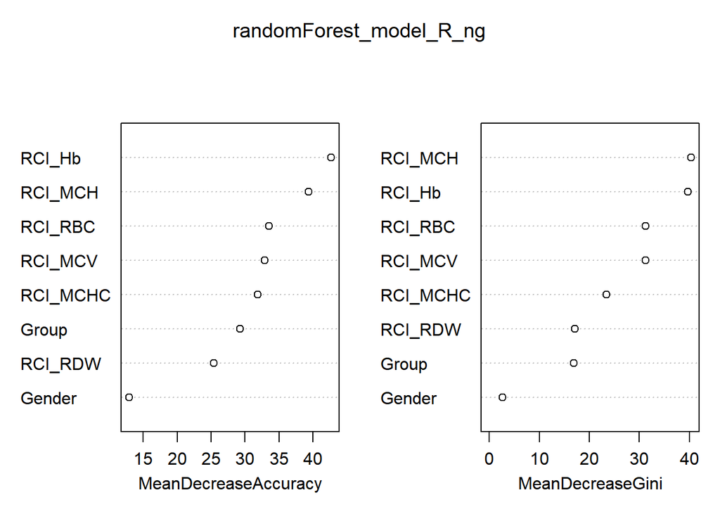

### Adaboost

```
## Confusion Matrix and Statistics
##
##           Reference
## Prediction ALPHA BETA IDA NORMAL
##     ALPHA      0    0   0      1
##     BETA       3   12   1     65
##     IDA        1    2  26     64
##     NORMAL     1    1   1    794
##
## Overall Statistics
##
##                Accuracy : 0.856
##                  95% CI : (0.8323, 0.8775)
##     No Information Rate : 0.9506
##     P-Value [Acc > NIR] : 1
##
##                   Kappa : 0.3347
##  Mcnemar's Test P-Value : <2e-16
##
## Statistics by Class:
##
##                      Class: ALPHA Class: BETA Class: IDA Class: NORMAL
## Sensitivity              0.000000     0.80000    0.92857        0.8593
## Specificity              0.998966     0.92790    0.92903        0.9375
## Pos Pred Value           0.000000     0.14815    0.27957        0.9962
## Neg Pred Value           0.994851     0.99663    0.99772        0.2571
## Precision                0.000000     0.14815    0.27957        0.9962
## Recall                   0.000000     0.80000    0.92857        0.8593
## F1                            NaN     0.25000    0.42975        0.9227
## Prevalence               0.005144     0.01543    0.02881        0.9506
## Detection Rate           0.000000     0.01235    0.02675        0.8169
## Detection Prevalence     0.001029     0.08333    0.09568        0.8200
## Balanced Accuracy        0.499483     0.86395    0.92880        0.8984
```

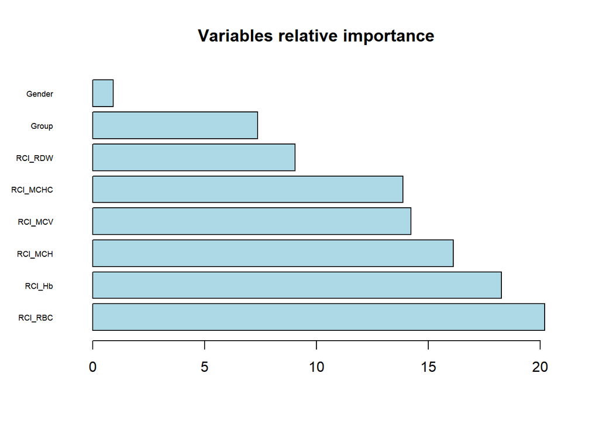

### XGBoost

```
## Confusion Matrix and Statistics
##
##           Reference
## Prediction ALPHA BETA IDA NORMAL
##     ALPHA      2    2   0      1
##     BETA       3   12   1     74
##     IDA        0    1  26     59
##     NORMAL     0    0   1    790
##
## Overall Statistics
##
##                Accuracy : 0.8539
##                  95% CI : (0.8301, 0.8755)
##     No Information Rate : 0.9506
##     P-Value [Acc > NIR] : 1
##
##                   Kappa : 0.3431
##  Mcnemar's Test P-Value : NA
##
## Statistics by Class:
##
##                      Class: ALPHA Class: BETA Class: IDA Class: NORMAL
## Sensitivity              0.400000     0.80000    0.92857        0.8550
## Specificity              0.996898     0.91850    0.93644        0.9792
## Pos Pred Value           0.400000     0.13333    0.30233        0.9987
## Neg Pred Value           0.996898     0.99660    0.99774        0.2597
## Precision                0.400000     0.13333    0.30233        0.9987
## Recall                   0.400000     0.80000    0.92857        0.8550
## F1                       0.400000     0.22857    0.45614        0.9213
## Prevalence               0.005144     0.01543    0.02881        0.9506
## Detection Rate           0.002058     0.01235    0.02675        0.8128
## Detection Prevalence     0.005144     0.09259    0.08848        0.8138
## Balanced Accuracy        0.698449     0.85925    0.93251        0.9171
```

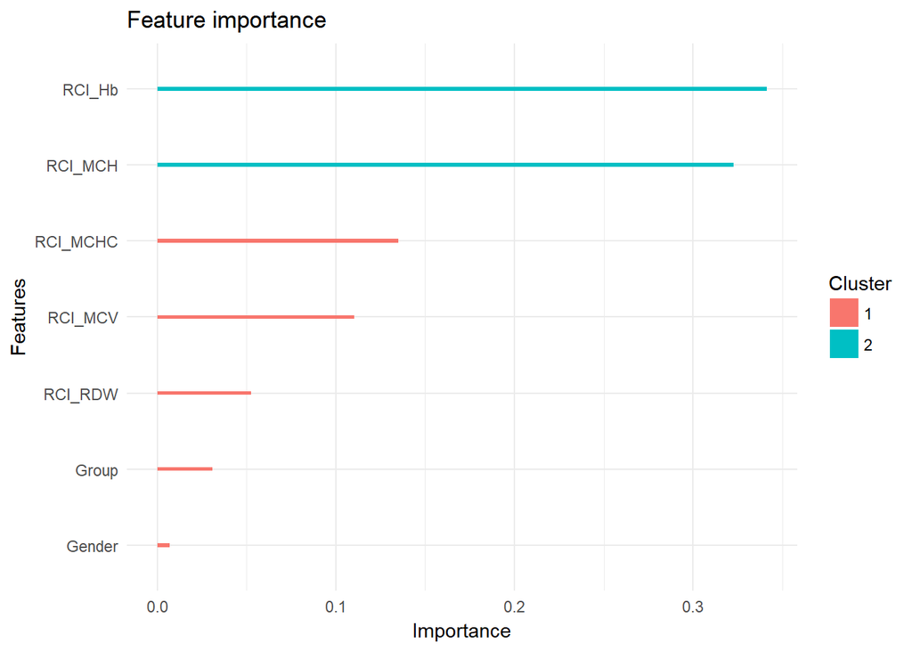

## Grid search result

Grid search is performed is each classifier to best tune the parameters for best outcome possible. It is performed with caret package with code provided below:

### Random Forest

- rf_grid <- expand.grid(mtry=c(1:8))
- Fitting mtry = 7 on full training set

### Adaboost

- ab_grid <- expand.grid(mfinal=c(50, 100), maxdepth=c(3, 5), coeflearn=c(“Breiman”, “Freund”, “Zhu”))
- Fitting mfinal = 50, maxdepth = 5, coeflearn = Freund on full training set

### XGBoost

- grid <- expand.grid(nrounds = c(100), max_depth = c(3, 4, 5, 6), eta = c(1, 0.5, 0.3, 0.01), gamma = c(0, 1), colsample_bytree = c(0.5, 1), min_child_weight = c(0.5, 1), subsample = c(0.5, 1) )
- Fitting nrounds = 100, max_depth = 5, eta = 1, gamma = 1, colsample_bytree = 0.5, min_child_weight = 0.5, subsample = 1 on full training set

## Model training

Each classifier is trained using the best tuning parameters provided by grid search. Nothing is special with random forest and adaboost, while xgboost is a special case that only received data in DMatrix format, therefore conversion is required as well as adjusting label with factor initially start with 1 to 0. As softmax is only providing the final result, softprob is providing the probability of selecting the final result, both are needed for ensemble method.

```r
#Random Forest for RCI*******************************************************
#Train model
set.seed(seed)
randomForest_model_R <- randomForest(train_tree_R$F_Diagnosis~., data=train_tree_R, importance=TRUE, mtry=7)

#Predict model
set.seed(seed)
rf_pred_R <- predict(randomForest_model_R, test_tree_R, type="response")

#AdaBoost for RCI***********************************************************
#Train model
ab_final_control = rpart.control(maxdepth=5)
set.seed(seed)
adaboost_model_R <- boosting(F_Diagnosis ~., data=train_tree_R, mfinal=50, coeflearn="Freund", control=ab_final_control)

#Predict model
set.seed(seed)
ab_pred_R <- predict(adaboost_model_R, test_tree_R, type="response")

#XGBoost for RCI*************************************************************
#transform dataframe to dmatrix
train_X_R <- data.matrix(train_tree_R[,1:7])
test_X_R <- data.matrix(test_tree_R[,1:7])
y <- as.matrix(as.numeric(train_tree_R$F_Diagnosis))
y <- y-1
dtrain_R <- xgb.DMatrix(data=train_X_R, label=y)
z <- as.matrix(as.numeric(test_tree_R$F_Diagnosis))
z <- z-1
dtest_R <- xgb.DMatrix(data=test_X_R, label=z)
watchlist_R <- list(train=dtrain_R, test=dtest_R)
numberOfClasses <- length(unique(thalassemiaSelected$F_Diagnosis))

#Train model
set.seed(seed)
xgboost_model_R <- xgb.train(
  data = dtrain_R,
  watchlist = watchlist_R,
  objective = "multi:softmax",
  num_class = numberOfClasses,
  verbose = 0,
  nrounds = 100,
  maxdepth = 5,
  eta = 1,
  gamma = 1,
  colsample_bytree = 0.5,
  min_child_weight = 0.5,
  subsample = 1
)

# Train predict model in probability
set.seed(seed)
xgboost_model_R_prob <- xgb.train(
  data = dtrain_R,
  watchlist = watchlist_R,
  objective = "multi:softprob",
  num_class = numberOfClasses,
  verbose = 0,
  nrounds = 100,
  maxdepth = 5,
  eta = 1,
  gamma = 1,
  colsample_bytree = 0.5,
  min_child_weight = 0.5,
  subsample = 1
)

#feature importance
features_R = colnames(train_X_R)
importance_matrix_R <- xgb.importance(features_R, model = xgboost_model_R)

#Predict model
pred_R <- predict(xgboost_model_R, dtest_R, type="response")
pred_R <- factor(pred_R)
levels(pred_R) <- levels(test_tree_R$F_Diagnosis)

#Ensemble for RCI*************************************************************
label_class = c("ALPHA","BETA","IDA","NORMAL")
usefulVar <- c('Gender','Group','RCI_Hb','RCI_MCH','RCI_MCV','RCI_MCHC','RCI_RDW','RCI_RBC','F_Diagnosis')
testSet <- test_tree_R
testSet$pred_rf <- rf_pred_R
testSet$pred_ab <- factor(ab_pred_R$class)
testSet$pred_xg <- pred_R

# Averaging==============================================================================
# Predicting the probabilities
set.seed(seed)
testSet$pred_rf_prob <- data.frame(predict(object = randomForest_model_R, testSet[,usefulVar], type='prob'))

pred_ab_prob <- data.frame(ab_pred_R$prob)
colnames(pred_ab_prob) <- label_class
testSet$pred_ab_prob <- pred_ab_prob

set.seed(seed)
pred_xg_prob <- matrix(predict(object = xgboost_model_R_prob, dtest_R, type='prob'), ncol = 4, byrow = T)
pred_xg_prob <- data.frame(pred_xg_prob)
colnames(pred_xg_prob) <- label_class
testSet$pred_xg_prob <- pred_xg_prob

# Taking average of predictions
testSet$pred_avg.ALPHA <- (testSet$pred_rf_prob$ALPHA + testSet$pred_ab_prob$ALPHA + testSet$pred_xg_prob$ALPHA)/3
testSet$pred_avg.BETA <- (testSet$pred_rf_prob$BETA + testSet$pred_ab_prob$BETA + testSet$pred_xg_prob$BETA)/3
testSet$pred_avg.IDA <- (testSet$pred_rf_prob$IDA + testSet$pred_ab_prob$IDA + testSet$pred_xg_prob$IDA)/3
testSet$pred_avg.NORMAL <- (testSet$pred_rf_prob$NORMAL + testSet$pred_ab_prob$NORMAL + testSet$pred_xg_prob$NORMAL)/3

# Get maximum average class
testSet$pred_avg <- colnames(testSet[, 16:19])[apply(testSet[, 16:19],1,which.max)]
testSet$pred_avg <- as.character(testSet$pred_avg)
testSet$pred_avg <- as.factor(gsub("pred_avg.", "", testSet$pred_avg))

#The majority vote========================================================================
# WARNING: NO HANDLING OF TIE MATCH

#label_class[as.numeric(names(which.max(table(as.numeric(testSet[1, 10:12])))))]
numeric_pred <- testSet[, 10:12]
numeric_pred$pred_rf <- as.numeric(numeric_pred$pred_rf)
numeric_pred$pred_ab <- as.numeric(numeric_pred$pred_ab)
numeric_pred$pred_xg <- as.numeric(numeric_pred$pred_xg)
chooseBestModel <- function(x) {
  tabulatedOutcomes <- table(x)
  sortedOutcomes <- sort(tabulatedOutcomes, decreasing=TRUE)
  mostCommonLabel <- names(sortedOutcomes)[1]
  mostCommonLabel
}
testSet$pred_majority <- as.factor(label_class[as.numeric(apply(numeric_pred, 1, chooseBestModel))])

#Taking weighted average of predictions===================================================
ratio_rf <- 0.2
ratio_ab <- 0.5
ratio_xg <- 0.3

testSet$pred_weighted_avg.ALPHA <- (testSet$pred_rf_prob$ALPHA*ratio_rf) + (testSet$pred_ab_prob$ALPHA*ratio_ab) + (testSet$pred_xg_prob$ALPHA*ratio_xg)
testSet$pred_weighted_avg.BETA <- (testSet$pred_rf_prob$BETA*ratio_rf) + (testSet$pred_ab_prob$BETA*ratio_ab) + (testSet$pred_xg_prob$BETA*ratio_xg)
testSet$pred_weighted_avg.IDA <- (testSet$pred_rf_prob$IDA*ratio_rf) + (testSet$pred_ab_prob$IDA*ratio_ab) + (testSet$pred_xg_prob$IDA*ratio_xg)
testSet$pred_weighted_avg.NORMAL <- (testSet$pred_rf_prob$NORMAL*ratio_rf) + (testSet$pred_ab_prob$NORMAL*ratio_ab) + (testSet$pred_xg_prob$NORMAL*ratio_xg)

# Get maximum weighted average class
testSet$pred_weighted_avg <-  colnames(testSet[, 22:25])[apply(testSet[, 22:25],1,which.max)]
testSet$pred_weighted_avg <- as.character(testSet$pred_weighted_avg)
testSet$pred_weighted_avg <- as.factor(gsub("pred_weighted_avg.", "", testSet$pred_weighted_avg))
```

## Classification Result

### Random Forest

```
## Confusion Matrix and Statistics
##
##           Reference
## Prediction ALPHA BETA IDA NORMAL
##     ALPHA      1    2   0      2
##     BETA       3   12   1     73
##     IDA        0    0  26     65
##     NORMAL     1    1   1    784
##
## Overall Statistics
##
##                Accuracy : 0.8467
##                  95% CI : (0.8225, 0.8688)
##     No Information Rate : 0.9506
##     P-Value [Acc > NIR] : 1
##
##                   Kappa : 0.3222
##  Mcnemar's Test P-Value : NA
##
## Statistics by Class:
##
##                      Class: ALPHA Class: BETA Class: IDA Class: NORMAL
## Sensitivity              0.200000     0.80000    0.92857        0.8485
## Specificity              0.995863     0.91954    0.93114        0.9375
## Pos Pred Value           0.200000     0.13483    0.28571        0.9962
## Neg Pred Value           0.995863     0.99660    0.99773        0.2432
## Precision                0.200000     0.13483    0.28571        0.9962
## Recall                   0.200000     0.80000    0.92857        0.8485
## F1                       0.200000     0.23077    0.43697        0.9164
## Prevalence               0.005144     0.01543    0.02881        0.9506
## Detection Rate           0.001029     0.01235    0.02675        0.8066
## Detection Prevalence     0.005144     0.09156    0.09362        0.8097
## Balanced Accuracy        0.597932     0.85977    0.92986        0.8930
```

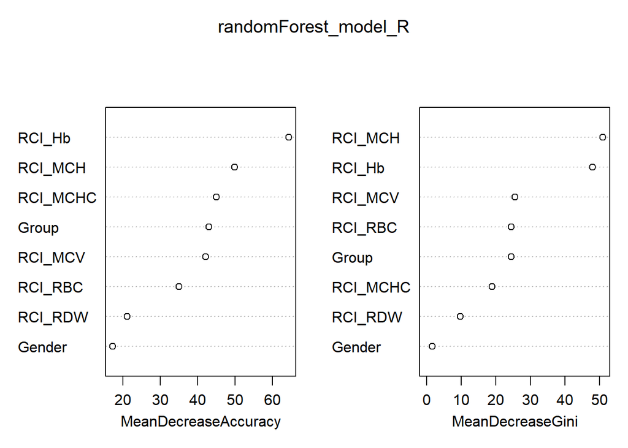

### Adaboost

```
## Confusion Matrix and Statistics
##
##           Reference
## Prediction ALPHA BETA IDA NORMAL
##     ALPHA      1    1   0      1
##     BETA       3   13   1     67
##     IDA        1    1  25     60
##     NORMAL     0    0   2    796
##
## Overall Statistics
##
##                Accuracy : 0.8591
##                  95% CI : (0.8356, 0.8803)
##     No Information Rate : 0.9506
##     P-Value [Acc > NIR] : 1
##
##                   Kappa : 0.3463
##  Mcnemar's Test P-Value : <2e-16
##
## Statistics by Class:
##
##                      Class: ALPHA Class: BETA Class: IDA Class: NORMAL
## Sensitivity              0.200000     0.86667    0.89286        0.8615
## Specificity              0.997932     0.92581    0.93432        0.9583
## Pos Pred Value           0.333333     0.15476    0.28736        0.9975
## Neg Pred Value           0.995872     0.99775    0.99661        0.2644
## Precision                0.333333     0.15476    0.28736        0.9975
## Recall                   0.200000     0.86667    0.89286        0.8615
## F1                       0.250000     0.26263    0.43478        0.9245
## Prevalence               0.005144     0.01543    0.02881        0.9506
## Detection Rate           0.001029     0.01337    0.02572        0.8189
## Detection Prevalence     0.003086     0.08642    0.08951        0.8210
## Balanced Accuracy        0.598966     0.89624    0.91359        0.9099
```

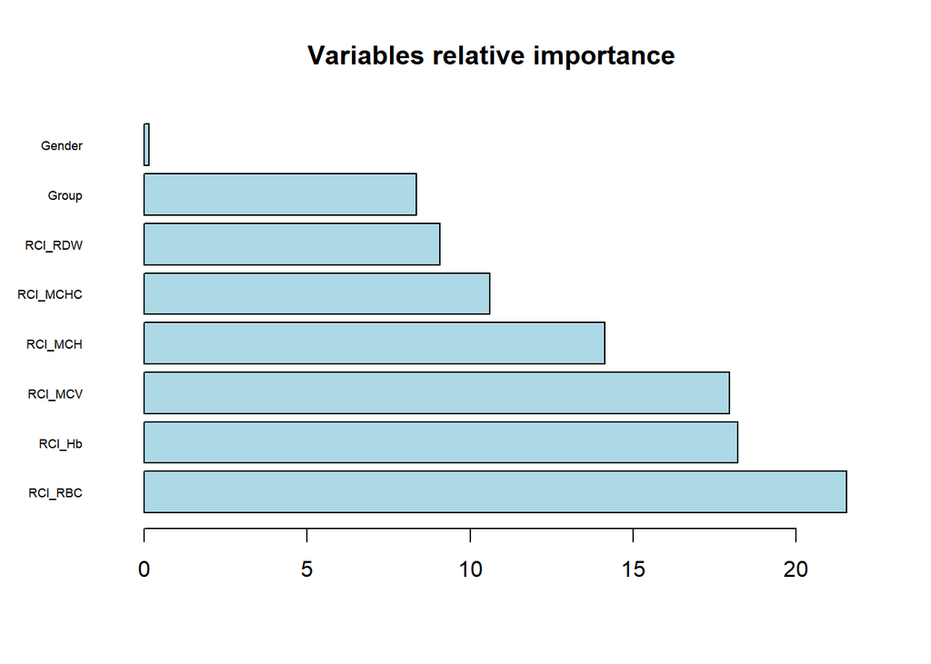

### XGBoost

```
## Confusion Matrix and Statistics
##
##           Reference
## Prediction ALPHA BETA IDA NORMAL
##     ALPHA      1    0   0      2
##     BETA       3   13   2     70
##     IDA        1    2  26     60
##     NORMAL     0    0   0    792
##
## Overall Statistics
##
##                Accuracy : 0.856
##                  95% CI : (0.8323, 0.8775)
##     No Information Rate : 0.9506
##     P-Value [Acc > NIR] : 1
##
##                   Kappa : 0.3494
##  Mcnemar's Test P-Value : <2e-16
##
## Statistics by Class:
##
##                      Class: ALPHA Class: BETA Class: IDA Class: NORMAL
## Sensitivity              0.200000     0.86667    0.92857        0.8571
## Specificity              0.997932     0.92163    0.93326        1.0000
## Pos Pred Value           0.333333     0.14773    0.29213        1.0000
## Neg Pred Value           0.995872     0.99774    0.99773        0.2667
## Precision                0.333333     0.14773    0.29213        1.0000
## Recall                   0.200000     0.86667    0.92857        0.8571
## F1                       0.250000     0.25243    0.44444        0.9231
## Prevalence               0.005144     0.01543    0.02881        0.9506
## Detection Rate           0.001029     0.01337    0.02675        0.8148
## Detection Prevalence     0.003086     0.09053    0.09156        0.8148
## Balanced Accuracy        0.598966     0.89415    0.93092        0.9286
```

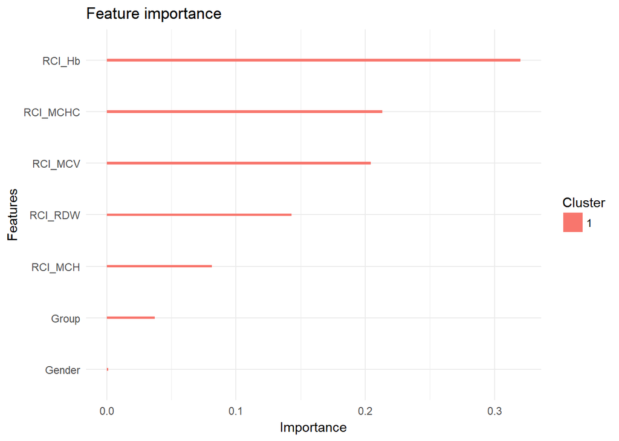

### Averaging

```
## Confusion Matrix and Statistics
##
##           Reference
## Prediction ALPHA BETA IDA NORMAL
##     ALPHA      1    0   0      2
##     BETA       4   14   1     69
##     IDA        0    1  27     59
##     NORMAL     0    0   0    794
##
## Overall Statistics
##
##                Accuracy : 0.8601
##                  95% CI : (0.8367, 0.8813)
##     No Information Rate : 0.9506
##     P-Value [Acc > NIR] : 1
##
##                   Kappa : 0.3625
##  Mcnemar's Test P-Value : NA
##
## Statistics by Class:
##
##                      Class: ALPHA Class: BETA Class: IDA Class: NORMAL
## Sensitivity              0.200000     0.93333    0.96429        0.8593
## Specificity              0.997932     0.92268    0.93644        1.0000
## Pos Pred Value           0.333333     0.15909    0.31034        1.0000
## Neg Pred Value           0.995872     0.99887    0.99887        0.2697
## Precision                0.333333     0.15909    0.31034        1.0000
## Recall                   0.200000     0.93333    0.96429        0.8593
## F1                       0.250000     0.27184    0.46957        0.9243
## Prevalence               0.005144     0.01543    0.02881        0.9506
## Detection Rate           0.001029     0.01440    0.02778        0.8169
## Detection Prevalence     0.003086     0.09053    0.08951        0.8169
## Balanced Accuracy        0.598966     0.92800    0.95036        0.9297
```

### Majority Vote

```
## Confusion Matrix and Statistics
##
##           Reference
## Prediction ALPHA BETA IDA NORMAL
##     ALPHA      1    1   0      1
##     BETA       4   13   1     72
##     IDA        0    1  26     62
##     NORMAL     0    0   1    789
##
## Overall Statistics
##
##                Accuracy : 0.8529
##                  95% CI : (0.829, 0.8746)
##     No Information Rate : 0.9506
##     P-Value [Acc > NIR] : 1
##
##                   Kappa : 0.3411
##  Mcnemar's Test P-Value : NA
##
## Statistics by Class:
##
##                      Class: ALPHA Class: BETA Class: IDA Class: NORMAL
## Sensitivity              0.200000     0.86667    0.92857        0.8539
## Specificity              0.997932     0.91954    0.93326        0.9792
## Pos Pred Value           0.333333     0.14444    0.29213        0.9987
## Neg Pred Value           0.995872     0.99773    0.99773        0.2582
## Precision                0.333333     0.14444    0.29213        0.9987
## Recall                   0.200000     0.86667    0.92857        0.8539
## F1                       0.250000     0.24762    0.44444        0.9207
## Prevalence               0.005144     0.01543    0.02881        0.9506
## Detection Rate           0.001029     0.01337    0.02675        0.8117
## Detection Prevalence     0.003086     0.09259    0.09156        0.8128
## Balanced Accuracy        0.598966     0.89310    0.93092        0.9165
```

### Weighted Averaging

Weighted Ratio:

- Random Forest = 0.2
- Adaboost = 0.5
- XGBoost Forest = 0.3

```
## Confusion Matrix and Statistics
##
##           Reference
## Prediction ALPHA BETA IDA NORMAL
##     ALPHA      1    0   0      2
##     BETA       4   14   1     68
##     IDA        0    1  27     62
##     NORMAL     0    0   0    792
##
## Overall Statistics
##
##                Accuracy : 0.858
##                  95% CI : (0.8345, 0.8794)
##     No Information Rate : 0.9506
##     P-Value [Acc > NIR] : 1
##
##                   Kappa : 0.3586
##  Mcnemar's Test P-Value : NA
##
## Statistics by Class:
##
##                      Class: ALPHA Class: BETA Class: IDA Class: NORMAL
## Sensitivity              0.200000     0.93333    0.96429        0.8571
## Specificity              0.997932     0.92372    0.93326        1.0000
## Pos Pred Value           0.333333     0.16092    0.30000        1.0000
## Neg Pred Value           0.995872     0.99887    0.99887        0.2667
## Precision                0.333333     0.16092    0.30000        1.0000
## Recall                   0.200000     0.93333    0.96429        0.8571
## F1                       0.250000     0.27451    0.45763        0.9231
## Prevalence               0.005144     0.01543    0.02881        0.9506
## Detection Rate           0.001029     0.01440    0.02778        0.8148
## Detection Prevalence     0.003086     0.08951    0.09259        0.8148
## Balanced Accuracy        0.598966     0.92853    0.94877        0.9286
```

### Test Set

Predictions with F_Diagnosis as reference

|  | F_Diagnosis | pred_rf | pred_ab | pred_xg | pred_avg | pred_majority | pred_weighted_avg |
| --- | --- | --- | --- | --- | --- | --- | --- |
| 1 | BETA | BETA | BETA | BETA | BETA | BETA | BETA |
| 2 | ALPHA | BETA | BETA | BETA | BETA | BETA | BETA |
| 5 | BETA | ALPHA | BETA | BETA | BETA | BETA | BETA |
| 6 | BETA | BETA | BETA | BETA | BETA | BETA | BETA |
| 8 | ALPHA | ALPHA | ALPHA | ALPHA | ALPHA | ALPHA | ALPHA |
| 10 | BETA | BETA | BETA | BETA | BETA | BETA | BETA |
| 17 | NORMAL | IDA | IDA | IDA | IDA | IDA | IDA |
| 28 | IDA | IDA | IDA | IDA | IDA | IDA | IDA |
| 35 | IDA | IDA | IDA | IDA | IDA | IDA | IDA |
| 39 | IDA | IDA | IDA | IDA | IDA | IDA | IDA |
| 40 | NORMAL | NORMAL | NORMAL | NORMAL | NORMAL | NORMAL | NORMAL |
| 42 | NORMAL | NORMAL | NORMAL | NORMAL | NORMAL | NORMAL | NORMAL |
| 43 | NORMAL | NORMAL | NORMAL | NORMAL | NORMAL | NORMAL | NORMAL |
| 45 | NORMAL | NORMAL | NORMAL | NORMAL | NORMAL | NORMAL | NORMAL |
| 46 | NORMAL | NORMAL | NORMAL | NORMAL | NORMAL | NORMAL | NORMAL |
| 48 | NORMAL | NORMAL | NORMAL | NORMAL | NORMAL | NORMAL | NORMAL |
| 49 | NORMAL | NORMAL | NORMAL | NORMAL | NORMAL | NORMAL | NORMAL |
| 53 | NORMAL | NORMAL | NORMAL | NORMAL | NORMAL | NORMAL | NORMAL |
| 55 | NORMAL | NORMAL | NORMAL | NORMAL | NORMAL | NORMAL | NORMAL |
| 57 | NORMAL | NORMAL | NORMAL | NORMAL | NORMAL | NORMAL | NORMAL |
| 59 | NORMAL | NORMAL | NORMAL | NORMAL | NORMAL | NORMAL | NORMAL |
| 61 | NORMAL | NORMAL | NORMAL | NORMAL | NORMAL | NORMAL | NORMAL |
| 64 | IDA | IDA | NORMAL | IDA | IDA | IDA | IDA |
| 65 | NORMAL | NORMAL | NORMAL | NORMAL | NORMAL | NORMAL | NORMAL |
| 67 | NORMAL | NORMAL | NORMAL | NORMAL | NORMAL | NORMAL | NORMAL |
| 71 | NORMAL | NORMAL | NORMAL | NORMAL | NORMAL | NORMAL | NORMAL |
| 78 | NORMAL | NORMAL | NORMAL | NORMAL | NORMAL | NORMAL | NORMAL |
| 79 | NORMAL | NORMAL | NORMAL | NORMAL | NORMAL | NORMAL | NORMAL |
| 81 | NORMAL | NORMAL | NORMAL | NORMAL | NORMAL | NORMAL | NORMAL |
| 85 | NORMAL | NORMAL | NORMAL | NORMAL | NORMAL | NORMAL | NORMAL |

[output cut: 942 more lines]